# TDI Project

### How does weather explain New York shooting’s rates?

**Objective**: For Data Incubator Project, I apply Bayesian Multilevel to model the rates of shooting in the City of Greater New York. While the second level of the model pools information across space (based on census data, the social and economic background), the first level simulate the trend and variability in response to the daily weather. This arrangement allows us to explore the variability of response with regard to the different social/economic background. If time permits, at the later stages of this investigation, I incorporate the effect of air quality (using AQI) to inform the rates of gun violence.

**Data**: For this analysis, I use multiple sources of information. This includes NYPD historical rate dataset (2006-2018), NCDC daily weather data, NYC census data (NYC open data and Department of City Planning). Later, I will include the AQI (Air Quality Index) to study the relevancy of air pollution to the occurrence of shooting. The time-span of observation considered in this analysis is 2006-2018.

#### Preliminary Analysis: Temporal Varaiblity

A sample of NYDP shooting dataset looks like the following:

```r
head(sample_of_data,4)
```

```
##     Borough Precinct Murder Age Group Sex      Lat       Lon      Dates
## 69 BROOKLYN       83  FALSE   UNKNOWN   M 40.69796 -73.91808 2007-09-09
## 79   QUEENS      103  FALSE     18-24   M 40.70548 -73.77248 2006-09-09
## 51    BRONX       47  FALSE       <18   M 40.88650 -73.84592 2008-09-09
## 25    BRONX       44  FALSE     18-24   M 40.84194 -73.91425 2011-09-09
```

During recent years, the New York shooting rates constantly decreased. This negative trends in year-to-year data can root from diffrent sources (such as increase in the number of police stations, education and etc.)

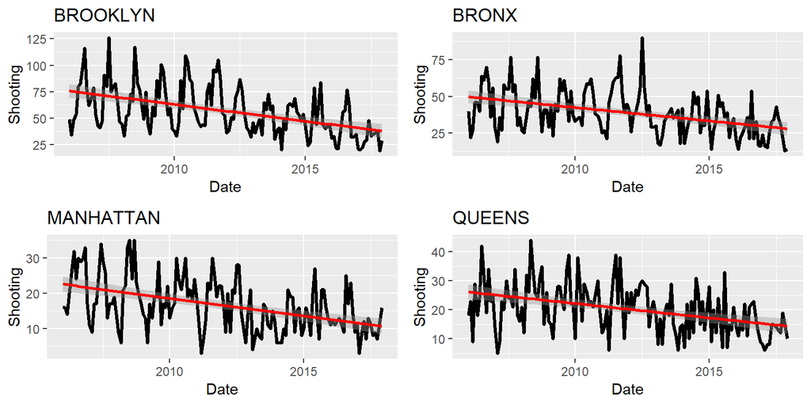

```r
grid.arrange(p1, p2, p3, p4, ncol = 2)
```

However, the shooting rates present a seasonal pattern, suggesting a correlation with weather variability. The Following figure shows that the number of incidents in the warmer months is higher than the shooting rates in colder seasons.

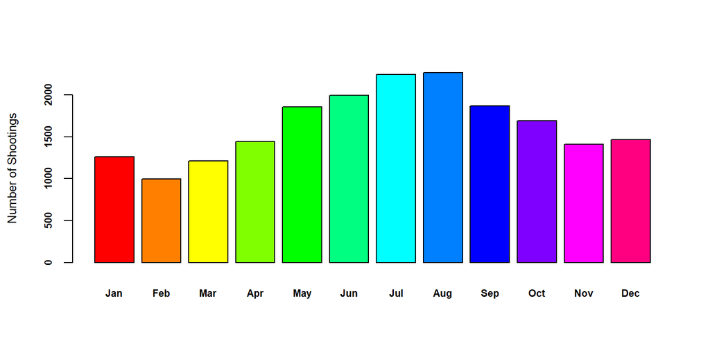

```r
df_plot <- aggregate(STATISTICAL_MURDER_FLAG~MONTH,as.data.frame(df),length)
barplot(sapply(1:12,function(x) length(df$STATISTICAL_MURDER_FLAG[which(df$MONTH==x)])),
        col=rainbow(12),names=month.abb[1:12],ylab='Number of Shootings',
        font=2,cex.axis = 0.7,cex.names=0.7,cex.lab=0.8)
```

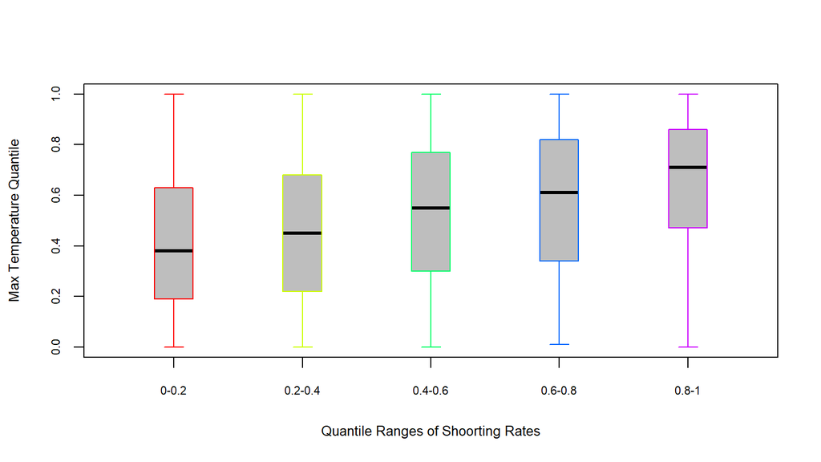

#### Preliminary Analysis: Spatial Varaiblity

The spatial distribution of shooting incident yields useable information on how the affected areas changed over time. The following map demonstrates the location of gun violence in 2007.

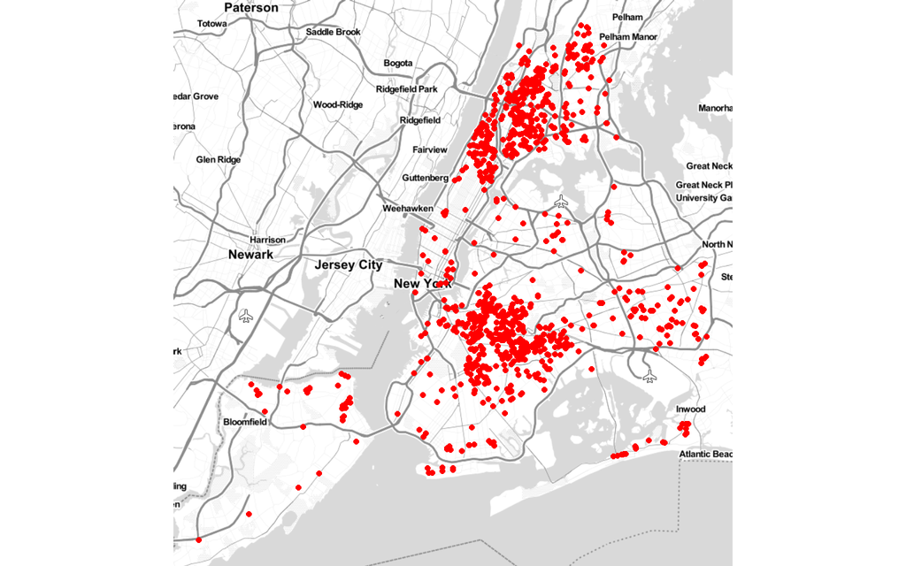

Using the Kernel estimators, I looked at the density of the number of incindents within 2-km radius. It is observed that the density of crimes decrease over time.

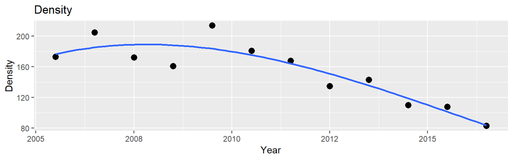

[figure not shown]